# GES816 – Moteur de décision de la méthode V2

AMA Variation « Best » + ADX(14) ≥ 17 + tendance hebdomadaire EMA 10/40 — trades du 28 septembre au 2 novembre 2026

École de technologie supérieure, Montréal

03/11/2026

École de technologie supérieure · Montréal

GES816 – Méthodes et systèmes d'investissement · Automne 2026 · Professeur : Edmond T. Miresco

# 1 À quoi sert ce moteur

Ce document est le moteur de décision de ma période de trading, du 28 septembre au 2 novembre 2026 (trades tenus aux prix de Yahoo Finance plutôt que dans MT5). Chaque jour, à la clôture, il fait pour chacun des quatre actifs (or, USO, AUDNZD, EURGBP) ce que je faisais à la main avec la méthode V2 :

1. **Il calcule les indicateurs** : `per` (AMA Variation « Best »), ADX(14), ATR(14) et la tendance hebdomadaire.
2. **Il décide** : ACHAT, VENTE, CONSERVER, SORTIE, STOP ou AUCUNE, et il écrit la raison avec les chiffres du jour.
3. **Il calcule la taille** de chaque position (1 % du capital risqué, stop à 2 × ATR) avec les contrats du compte démo.
4. **Il compte les coûts** (swap, spread, glissement) et suit le capital, le drawdown et les limites de risque du compte.
5. **Il se contrôle** : relancé sur la période de mon journal (28 septembre – 30 octobre), il doit retrouver les cinq trades du journal, quantités et P&L, à 0,01 $ près.

|  | Ce moteur | Backtest (`GES816_backtest_4_actifs.Rmd`) |
| --- | --- | --- |
| Période | 28 sept. – 2 nov. 2026 : mes trades | 2003 – 25 sept. 2026 : l’historique |
| But | produire et justifier chaque décision | mesurer la règle sur 23 ans |
| Résultat | P&L en dollars (quantités, swaps et spreads du compte démo) | résultat en R (multiples du risque) |
| Pétrole | ETF USO | contrat à terme WTI (CL=F) |
| Forex | barres reconstruites à 17 h, heure de New York | barres Yahoo de minuit à Londres, corrigées |

Le même code existe en script, `GES816_V2_moteur.R` (à lancer avec `Rscript`, il écrit seulement les CSV du dossier `sorties/`). Ce document contient ce code, l’explique et produit le rapport HTML.

**Pour l’exécuter** : ouvrir ce fichier dans RStudio et cliquer sur *Knit* (connexion Internet requise). Avec `source = "yahoo"` (par défaut), le document télécharge lui-même tous les cours sur Yahoo Finance et les enregistre dans le dossier `data_yahoo/`. Avec `source = "csv"`, il lit plutôt le dossier `data/` du zip d’origine (`GES816_V2_R.zip`), placé à côté de ce fichier.

# 2 Règles de la méthode V2

| Élément | Règle |
| --- | --- |
| Signal de momentum | AMA de Kaufman (21, 2, 30), lissée sur 2 barres ; dif = AMA lissée − AMA lissée 2 barres avant ; **per = EMA(dif, 21)** |
| Filtre de force | ADX(14) de Wilder **≥ 17** |
| Filtre de tendance | EMA 10 et EMA 40 des clôtures hebdomadaires, **dernière semaine terminée** seulement |
| Achat | per ≥ 0 **et** tendance hebdo haussière (EMA10 > EMA40) **et** ADX ≥ 17 |
| Vente | per < 0 **et** tendance hebdo baissière (EMA10 < EMA40) **et** ADX ≥ 17 |
| Sortie | à la clôture, dès qu’une des trois conditions n’est plus vraie, ou stop touché en séance |
| Stop-loss | 2 × ATR(14) depuis le prix d’entrée, fixe. **Aucun take-profit** : la sortie se fait sur le signal |
| Taille | 1 % du capital / (2 × ATR × valeur du point par lot), arrondi vers le bas au pas de volume |
| Limites du compte | 5 positions maximum, perte journalière de 5 %, drawdown de 10 % |

# 3 Paquets et fichiers de cours

Les paquets manquants sont installés automatiquement (une seule fois). Le moteur lui-même n’utilise que R de base : les paquets servent aux tableaux et aux graphiques du rapport.

```r
paquets <- c("knitr", "rmarkdown", "kableExtra", "ggplot2", "DT", "curl", "jsonlite")
manquants <- paquets[!vapply(paquets, requireNamespace, logical(1), quietly = TRUE)]
if (length(manquants)) install.packages(manquants, repos = "https://cloud.r-project.org")
suppressPackageStartupMessages({ library(knitr); library(kableExtra); library(ggplot2); library(DT) })
tab <- function(x, ...) kbl(x, format = "html", ...) |>
  kable_styling(bootstrap_options = c("striped", "condensed", "hover"), full_width = FALSE, font_size = 13)

if (params$source == "csv") {          # mode csv : fichiers du zip d'origine dans le dossier "data"
  fichiers <- file.path("data", c("XAUUSD.csv", "USO.csv", "AUDNZD.csv", "EURGBP.csv", paste0("FX_", params$fin, ".csv")))
  absents <- fichiers[!file.exists(fichiers)]
  if (length(absents)) stop("Fichiers introuvables dans le dossier ", file.path(normalizePath(".", winslash = "/"), "data"),
                            " : ", paste(basename(absents), collapse = ", "),
                            ". Copier à côté de ce .Rmd le dossier data/ du zip GES816_V2_R.zip, ou utiliser source = \"yahoo\".")
}
```

# 4 Téléchargement des cours sur Yahoo Finance

Les cours sont lus directement sur l’API de Yahoo Finance (celle qu’utilise `quantmod`). `quantmod` ne sert pas ici : il ne donne que 7 jours de cours horaires, alors que le forex en demande près de deux ans.

- **Or (GC=F) et USO** : cours journaliers, datés dans le fuseau de la bourse (New York).
- **AUDNZD et EURGBP** : la barre journalière forex de Yahoo est défectueuse (sa « clôture » est en fait l’ouverture). Les barres journalières sont donc reconstruites à partir des cours horaires : une séance va de 17 h la veille à 17 h, heure de New York, comme sur MT5. Yahoo ne garde les cours horaires que 730 jours.
- **Taux NZDUSD et GBPUSD** : clôture de 17 h, heure de New York, le dernier jour de la période, pour convertir le P&L en dollars.

```r
FIN_DONNEES <- as.Date(params$fin)                    # même date que FIN ci-dessous

yahoo <- function(tk, de, a, intervalle) {            # une requête à l'API « chart » de Yahoo Finance
  url <- sprintf("https://query2.finance.yahoo.com/v8/finance/chart/%s?period1=%.0f&period2=%.0f&interval=%s",
                 utils::URLencode(tk, reserved = TRUE), as.numeric(as.POSIXct(as.Date(de))),
                 as.numeric(as.POSIXct(as.Date(a))), intervalle)
  rep <- curl::curl_fetch_memory(url, handle = curl::new_handle(useragent = "Mozilla/5.0"))
  if (rep$status_code != 200) stop("Yahoo Finance a refusé ", tk, " (code ", rep$status_code, ") : ", rawToChar(rep$content))
  y <- jsonlite::fromJSON(rawToChar(rep$content))$chart$result
  q <- unlist(y$indicators$quote[[1]], recursive = FALSE)
  x <- data.frame(t = .POSIXct(y$timestamp[[1]], tz = y$meta$exchangeTimezoneName),
                  Open = q$open, High = q$high, Low = q$low, Close = q$close)
  x[stats::complete.cases(x), ]
}
propre <- function(d) {                               # une barre par date, plus haut et plus bas cohérents
  d <- d[order(d$Date), ]; d <- d[!duplicated(d$Date, fromLast = TRUE) & d$Date <= FIN_DONNEES, ]
  d$High <- pmax(d$High, d$Open, d$Close); d$Low <- pmin(d$Low, d$Open, d$Close)
  rownames(d) <- NULL; d
}
journalier <- function(tk, de) {                      # date de la séance dans le fuseau de la bourse
  x <- yahoo(tk, de, FIN_DONNEES + 3, "1d")
  propre(data.frame(Date = as.Date(format(x$t, "%Y-%m-%d", tz = attr(x$t, "tzone"))), x[, -1]))
}
barres_17h <- function(tk, de) {                      # forex : séance de 17 h (veille) à 17 h, heure de New York
  x <- yahoo(tk, de, FIN_DONNEES + 3, "1h")           # horodatage = début de l'heure
  jour <- as.Date(format(x$t + 7 * 3600, "%Y-%m-%d", tz = "America/New_York"))   # 17 h -> séance du lendemain
  b <- data.frame(Date = as.Date(names(split(x$Open, jour))),
                  Open = vapply(split(x$Open, jour), function(v) v[1], 0), High = vapply(split(x$High, jour), max, 0),
                  Low = vapply(split(x$Low, jour), min, 0), Close = vapply(split(x$Close, jour), function(v) v[length(v)], 0))
  propre(b[!format(b$Date, "%u") %in% c("6", "7"), ])
}
ecrire <- function(d, f) {                            # 17 chiffres : le fichier relu redonne exactement les mêmes cours
  d[-1] <- lapply(d[-1], sprintf, fmt = "%.17g"); write.csv(d, f, row.names = FALSE, quote = FALSE)
}

debut_horaire <- max(as.Date("2024-01-15"), Sys.Date() - 728)     # limite de 730 jours de Yahoo
cours <- list(XAUUSD = journalier("GC=F", "2024-01-16"), USO = journalier("USO", "2024-01-16"),
              AUDNZD = barres_17h("AUDNZD=X", debut_horaire), EURGBP = barres_17h("EURGBP=X", debut_horaire))
taux <- vapply(c(NZDUSD = "NZDUSD=X", GBPUSD = "GBPUSD=X"), function(tk) {
  b <- barres_17h(tk, FIN_DONNEES - 10); b$Close[b$Date == FIN_DONNEES]
}, numeric(1))

dir.create("data_yahoo", showWarnings = FALSE)
for (a in names(cours)) ecrire(cours[[a]], file.path("data_yahoo", paste0(a, ".csv")))
write.csv(data.frame(Pair = names(taux), Rate = sprintf("%.17g", taux)), file.path("data_yahoo", paste0("FX_", params$fin, ".csv")),
          row.names = FALSE, quote = FALSE)
tab(data.frame(Actif = names(cours), Source = c("GC=F journalier", "USO journalier", "AUDNZD=X horaire -> 17 h NY", "EURGBP=X horaire -> 17 h NY"),
               Début = sapply(cours, function(d) format(min(d$Date))), Fin = sapply(cours, function(d) format(max(d$Date))),
               Séances = sapply(cours, nrow), check.names = FALSE), row.names = FALSE,
    caption = sprintf("Cours téléchargés le %s ; taux du %s : NZDUSD %.5f, GBPUSD %.5f (journal du 30/10 : 0,56322 et 1,33910)",
                      format(Sys.Date(), "%d/%m/%Y"), format(FIN_DONNEES, "%d/%m/%Y"), taux[["NZDUSD"]], taux[["GBPUSD"]]))
```

Cours téléchargés le 03/11/2026 ; taux du 02/11/2026 : NZDUSD 0.56180, GBPUSD 1.34066 (journal du 30/10 : 0,56322 et 1,33910)

| Actif | Source | Début | Fin | Séances |
| --- | --- | --- | --- | --- |
| XAUUSD | GC=F journalier | 2024-01-16 | 2026-11-02 | 705 |
| USO | USO journalier | 2024-01-16 | 2026-11-02 | 703 |
| AUDNZD | AUDNZD=X horaire -> 17 h NY | 2024-11-05 | 2026-11-02 | 520 |
| EURGBP | EURGBP=X horaire -> 17 h NY | 2024-11-05 | 2026-11-02 | 520 |

# 5 Paramètres et spécifications des contrats

Tous les réglages de la méthode sont regroupés ici. `pv` est le gain en dollars pour une variation de 1,0 du prix, par lot (ou par action pour USO). Pour AUDNZD et EURGBP, le gain est en NZD ou en GBP : il est converti en dollars au taux du dernier jour de la période.

```r
CAPITAL   <- 50000                     # capital de départ ($)
DEBUT     <- as.Date("2026-09-28")     # première séance de décision
FIN       <- as.Date(params$fin)       # dernière séance : clôture forcée de tout
DOSSIER   <- if (params$source == "yahoo") "data_yahoo" else "data"   # CSV : Date,Open,High,Low,Close

AMA_N <- 21; AMA_FAST <- 2; AMA_SLOW <- 30   # AMA de Kaufman 21/2/30
PER_EMA  <- 21                              # per = EMA(dif, 21)
ADX_N    <- 14; ADX_MIN <- 17               # filtre de force de tendance
ATR_N    <- 14; ATR_MULT <- 2               # stop = 2 x ATR(14)
RISQUE   <- 0.01                            # 1 % du capital risqué par trade
W_FAST   <- 10; W_SLOW <- 40                # EMA hebdomadaires 10 / 40
MAX_POS  <- 5                               # positions simultanées max
PERTE_JOUR_MAX <- 0.05                      # perte journalière max 5 %
DD_MAX   <- 0.10                            # drawdown max 10 %

# Taux de change (clôture du dernier jour) pour convertir le P&L en $
FX     <- read.csv(file.path(DOSSIER, paste0("FX_", format(FIN), ".csv")))
NZDUSD <- FX$Rate[FX$Pair == "NZDUSD"]
GBPUSD <- FX$Rate[FX$Pair == "GBPUSD"]

# Spécifications des contrats (compte MetaQuotes-Demo, 30 oct. 2026)
#  pv     = $ gagnés pour une variation de 1,0 du prix, par lot (ou par action)
#  swap_* = points par lot et par nuit (négatif = coût), triple le mercredi
#  spread = points ; slip = glissement par ordre, en unité de prix
SPEC <- list(
  XAUUSD = list(nom = "Or (XAUUSD)",       point = 0.01,  pv = 10,            step = 0.01, unite = "lot",
                swap_long = -12.6, swap_short = -4.6,  triple = TRUE,  spread = 31, slip = 31 * 0.01 / 2, dec = 2),
  USO    = list(nom = "Pétrole (ETF USO)", point = 0.01,  pv = 1,             step = 1,    unite = "action",
                swap_long = 0,     swap_short = 0,     triple = FALSE, spread = 2,  slip = 0.01,          dec = 2),
  AUDNZD = list(nom = "AUDNZD",            point = 1e-5,  pv = 1e5 * NZDUSD,  step = 0.01, unite = "lot",
                swap_long = -2.5,  swap_short = -15.2, triple = TRUE,  spread = 3,  slip = 3 * 1e-5 / 2,  dec = 5),
  EURGBP = list(nom = "EURGBP",            point = 1e-5,  pv = 1e5 * GBPUSD,  step = 0.01, unite = "lot",
                swap_long = -1.2,  swap_short = -0.4,  triple = TRUE,  spread = 0,  slip = 0,             dec = 5)
)
ACTIFS <- names(SPEC)
```

Fonctions utilitaires : décalage d’une série, mise en forme des nombres, moyenne mobile exponentielle (EMA).

```r
decale <- function(x, k) c(rep(NA, k), head(x, -k))           # x[t-k]
num <- function(x, d = 2) formatC(x, format = "f", digits = d, big.mark = "\u00a0", decimal.mark = ",")
px  <- function(x, a) num(x, SPEC[[a]]$dec)                    # prix au format de l'actif
fper <- function(x) formatC(x, digits = 4, format = "g", decimal.mark = ",")    # valeur de per (4 chiffres significatifs)
qte <- function(l, a) if (SPEC[[a]]$unite == "lot") paste(num(l, 2), "lot") else paste(l, "actions")

ema <- function(x, span) {                     # EMA récursive (pandas adjust = FALSE)
  a <- 2 / (span + 1); out <- rep(NA_real_, length(x))
  i0 <- which(!is.na(x))[1]
  if (is.na(i0)) return(out)
  out[i0] <- x[i0]
  if (i0 < length(x)) for (i in (i0 + 1):length(x)) out[i] <- a * x[i] + (1 - a) * out[i - 1]
  out
}
```

Spécifications utilisées (compte MetaQuotes-Demo, 30 oct. 2026)

| Actif | Nom | Valeur de 1,0 de prix ($/lot) | Pas de volume | Swap long (pts) | Swap court (pts) | Spread (pts) |
| --- | --- | --- | --- | --- | --- | --- |
| XAUUSD | Or (XAUUSD) | 10,00 | 0.01 lot | -12.6 | -4.6 | 31 |
| USO | Pétrole (ETF USO) | 1,00 | 1 action | 0.0 | 0.0 | 2 |
| AUDNZD | AUDNZD | 56 179,77 | 0.01 lot | -2.5 | -15.2 | 3 |
| EURGBP | EURGBP | 134 066,24 | 0.01 lot | -1.2 | -0.4 | 0 |

# 6 Données

`charger()` lit les cours d’un actif et vérifie qu’aucune date n’est en double et que le plus haut et le plus bas encadrent bien l’ouverture et la clôture.

```r
charger <- function(a) {
  d <- read.csv(file.path(DOSSIER, paste0(a, ".csv")))
  d$Date <- as.Date(d$Date)
  d <- d[order(d$Date), ]
  stopifnot(!anyDuplicated(d$Date), all(d$High >= pmax(d$Open, d$Close)), all(d$Low <= pmin(d$Open, d$Close)))
  d
}
DATA <- setNames(lapply(ACTIFS, charger), ACTIFS)
```

```r
derniere_seance <- as.Date(sapply(DATA, function(d) max(d$Date)), origin = "1970-01-01")
if (any(derniere_seance < FIN)) stop("Les cours du ", format(FIN, "%d/%m/%Y"), " ne sont pas encore disponibles pour : ",
                                     paste(ACTIFS[derniere_seance < FIN], collapse = ", "), ". Relancer plus tard.")
```

Historique chargé : il sert à amorcer l’AMA, l’ADX et l’EMA hebdomadaire 40

| Actif | Séances | Début | Fin | Clôture 28/09/2026 | Dernière clôture |
| --- | --- | --- | --- | --- | --- |
| XAUUSD | 705 | 2024-01-16 | 2026-11-02 | 4 168,40 | 3 969,60 |
| USO | 703 | 2024-01-16 | 2026-11-02 | 150,01 | 156,87 |
| AUDNZD | 520 | 2024-11-05 | 2026-11-02 | 1,23822 | 1,24530 |
| EURGBP | 520 | 2024-11-05 | 2026-11-02 | 0,85778 | 0,83427 |

**Sources** (Yahoo Finance) : or = contrat à terme GC=F ; USO = cours NYSE ; AUDNZD et EURGBP = barres reconstruites à partir des cours horaires, clôture à 17 h, heure de New York. Source utilisée pour cette exécution : **téléchargement Yahoo Finance du 03/11/2026**.

**Contrôle des cours.** Les clôtures chargées sont comparées à celles de mon journal, séance par séance, sur la période des trades. Yahoo révise parfois ses cours (l’or du 30 octobre est passé de 3 884,90 à 3 898,90) : un petit écart est possible, mais un écart important signalerait un problème de données.

```r
journal_clotures <- data.frame(
  Date = as.Date(c("2026-09-28", "2026-09-29", "2026-09-30", "2026-10-01", "2026-10-02", "2026-10-05", "2026-10-06",
                   "2026-10-07", "2026-10-08", "2026-10-09", "2026-10-12", "2026-10-13", "2026-10-14", "2026-10-15",
                   "2026-10-16", "2026-10-19", "2026-10-20", "2026-10-21", "2026-10-22", "2026-10-23", "2026-10-26",
                   "2026-10-27", "2026-10-28", "2026-10-29", "2026-10-30")),
  XAUUSD = c(4168.4, 4179.7, 4186.7, 4202.3, 4162.3, 4156.8, 4187.1, 4140.7, 4157, 4216.3, 4190.6, 4177.3, 4107.9,
             4170.1, 4181.1, 4160.1, 4142.6, 4150, 4060.4, 4007.9, 4038.4, 4074.6, 4051.6, 4031.4, 3898.9),
  USO = c(150.01, 143.35, 145.66, 150.02, 147.37, 143.99, 144.91, 143.91, 147.58, 148.2, 151.03, 153.09, 153.56,
          157.31, 161.76, 160.81, 160.61, 159.8, 162.51, 169.53, 166.23, 163.88, 166.57, 168.19, 168.83),
  AUDNZD = c(1.23822, 1.23767, 1.23227, 1.23559, 1.23755, 1.24429, 1.2409, 1.24291, 1.23963, 1.24262, 1.24442,
             1.24334, 1.24614, 1.23052, 1.22759, 1.2315, 1.23165, 1.23216, 1.23469, 1.23386, 1.23471, 1.23558,
             1.25356, 1.24694, 1.24816),
  EURGBP = c(0.85778, 0.85705, 0.85397, 0.85158, 0.84949, 0.8483, 0.84792, 0.84714, 0.84737, 0.84624, 0.84428,
             0.84478, 0.84546, 0.84492, 0.84313, 0.84265, 0.83961, 0.83846, 0.83668, 0.83739, 0.83733, 0.83591,
             0.83699, 0.83502, 0.83307))
ecarts <- do.call(rbind, lapply(ACTIFS, function(a) {
  r <- DATA[[a]]$Close[match(journal_clotures$Date, DATA[[a]]$Date)]
  e <- abs(r / journal_clotures[[a]] - 1)
  data.frame(Actif = a, `Séances comparées` = sum(!is.na(r)), `Séances manquantes` = sum(is.na(r)),
             `Clôtures identiques (à 0,01 % près)` = sum(e < 1e-4, na.rm = TRUE),
             `Écart max` = sprintf("%.3f %%", 100 * max(e, na.rm = TRUE)),
             `Date de l'écart max` = format(journal_clotures$Date[which.max(e)]), check.names = FALSE)
}))
tab(ecarts, row.names = FALSE, caption = "Clôtures chargées comparées à celles du journal (28 sept. – 30 oct. 2026)")
```

Clôtures chargées comparées à celles du journal (28 sept. – 30 oct. 2026)

| Actif | Séances comparées | Séances manquantes | Clôtures identiques (à 0,01 % près) | Écart max | Date de l’écart max |
| --- | --- | --- | --- | --- | --- |
| XAUUSD | 25 | 0 | 25 | 0.000 % | 2026-10-07 |
| USO | 25 | 0 | 25 | 0.000 % | 2026-10-28 |
| AUDNZD | 25 | 0 | 25 | 0.000 % | 2026-09-29 |
| EURGBP | 25 | 0 | 25 | 0.000 % | 2026-10-08 |

# 7 Indicateurs

1. **AMA de Kaufman (21, 2, 30).** Le ratio d’efficience ER = |C − C[21]| / somme des |variations| sur 21 jours vaut 1 quand le prix va tout droit et 0 quand il fait du bruit. La vitesse de la moyenne suit ER : rapide (2) en tendance, lente (30) dans le bruit.
2. **AMA Variation « Best ».** L’AMA est lissée sur 2 barres, sa pente sur 2 barres est calculée, puis lissée par une EMA 21 : c’est `per`. `per ≥ 0` signale un momentum haussier, `per < 0` un momentum baissier.
3. **ADX(14) et ATR(14) de Wilder.** L’ADX mesure la force de la tendance (seuil 17). L’ATR mesure l’amplitude moyenne d’une séance ; il fixe la distance du stop et donc la taille de la position.
4. **Tendance hebdomadaire.** EMA 10 et EMA 40 des clôtures du vendredi. Le moteur n’utilise que la **dernière semaine terminée** : une décision du mercredi ne voit pas la clôture du vendredi suivant.

```r
# 1) AMA de Kaufman : ER = |C - C[n]| / somme|dC| ; sc = (ER*(f - s) + s)^2
ama_kaufman <- function(c, n = AMA_N, fast = AMA_FAST, slow = AMA_SLOW) {
  f <- 2 / (fast + 1); s <- 2 / (slow + 1)
  ama <- rep(NA_real_, length(c))
  ama[n + 1] <- c[n + 1]                                       # amorçage
  for (i in (n + 2):length(c)) {
    vol <- sum(abs(diff(c[(i - n):i])))
    er  <- if (vol > 0) abs(c[i] - c[i - n]) / vol else 0
    sc  <- (er * (f - s) + s)^2
    ama[i] <- sc * c[i] + (1 - sc) * ama[i - 1]
  }
  ama
}

# 2) Variation "Best" : AMA lissée sur 2 barres, pente sur 2 barres, puis EMA 21
ama_best <- function(c) {
  ama  <- ama_kaufman(c)
  amas <- (ama + decale(ama, 1)) / 2
  dif  <- amas - decale(amas, 2)
  data.frame(ama = ama, per = ema(dif, PER_EMA))
}

# 3) ADX(14) et ATR(14) de Wilder
lissage_wilder <- function(x, n) {             # TR14, +DM14, -DM14 (version somme)
  out <- rep(NA_real_, length(x))
  out[n + 1] <- sum(x[2:(n + 1)])
  for (i in (n + 2):length(x)) out[i] <- out[i - 1] - out[i - 1] / n + x[i]
  out
}
adx_atr <- function(h, l, c, n = ADX_N) {
  pc  <- decale(c, 1)
  tr  <- pmax(h - l, abs(h - pc), abs(l - pc))
  up  <- h - decale(h, 1); dn <- decale(l, 1) - l
  pdm <- ifelse(up > dn & up > 0, up, 0); mdm <- ifelse(dn > up & dn > 0, dn, 0)
  pdi <- 100 * lissage_wilder(pdm, n) / lissage_wilder(tr, n)
  mdi <- 100 * lissage_wilder(mdm, n) / lissage_wilder(tr, n)
  dx  <- 100 * abs(pdi - mdi) / (pdi + mdi)
  adx <- rep(NA_real_, length(c)); v0 <- which(!is.na(dx))[1]; k <- v0 + n - 1
  adx[k] <- mean(dx[v0:k])
  for (i in (k + 1):length(c)) adx[i] <- (adx[i - 1] * (n - 1) + dx[i]) / n
  atr <- rep(NA_real_, length(c))
  atr[ATR_N + 1] <- mean(tr[2:(ATR_N + 1)])
  for (i in (ATR_N + 2):length(c)) atr[i] <- (atr[i - 1] * (ATR_N - 1) + tr[i]) / ATR_N
  data.frame(adx = adx, atr = atr, pdi = pdi, mdi = mdi)
}

# 4) Tendance hebdomadaire : EMA10 vs EMA40 des clôtures du vendredi,
#    en n'utilisant que la DERNIÈRE SEMAINE TERMINÉE (pas de regard vers le futur)
tendance_hebdo <- function(dates, close) {
  wd   <- as.POSIXlt(dates)$wday
  vend <- dates + (5 - wd + 7) %% 7                       # vendredi de la semaine
  der  <- !duplicated(vend, fromLast = TRUE)              # dernière séance de chaque semaine
  sem  <- vend[der]; e10 <- ema(close[der], W_FAST); e40 <- ema(close[der], W_SLOW)
  j <- match(vend, sem) - 1; j[j < 1] <- NA               # semaine précédente
  data.frame(tw = ifelse(e10 > e40, 1, -1)[j], ema10_sem = e10[j], ema40_sem = e40[j], semaine_ref = sem[j])
}
```

Un signal d’achat (`long_ok`) exige les trois conditions d’achat le même jour ; de même pour la vente (`short_ok`).

```r
signaux <- function(d) {
  s <- cbind(d, ama_best(d$Close), adx_atr(d$High, d$Low, d$Close), tendance_hebdo(d$Date, d$Close))
  s$adx_veille <- decale(s$adx, 1)
  adx_ok     <- !is.na(s$adx) & s$adx >= ADX_MIN
  s$long_ok  <- adx_ok & !is.na(s$per) & s$per >= 0 & !is.na(s$tw) & s$tw == 1
  s$short_ok <- adx_ok & !is.na(s$per) & s$per <  0 & !is.na(s$tw) & s$tw == -1
  s
}
SIG <- lapply(DATA, signaux)
```

# 8 Moteur de décision

Chaque jour de la période, et pour chaque actif, le moteur suit cet ordre :

1. **Stop.** Si une position ouverte un jour précédent a touché son stop pendant la séance, elle est fermée au stop (ou à l’ouverture si le cours a ouvert au-delà du stop).
2. **Limites du compte.** Si la perte du jour atteint 5 % ou le drawdown 10 %, tout est fermé.
3. **Décision à la clôture.** Il **sort** si une condition est perdue ; sinon il **conserve**. Sans position, il **entre** si les trois conditions sont réunies.
4. **Fin de période.** Le dernier jour (02/11/2026), il ferme tout au cours de clôture.

Ces fonctions écrivent la justification de chaque décision, avec les valeurs des indicateurs.

```r
# Textes qui justifient chaque décision (entrée, maintien, sortie, absence de signal)
txt_tendance <- function(b) sprintf("tendance hebdo %s (EMA10 %s EMA40, semaine du %s)",
  ifelse(b$tw == 1, "haussière", "baissière"), ifelse(b$tw == 1, ">", "<"), format(b$semaine_ref, "%d/%m"))

raison_entree <- function(b, a, sens, lots, cap) {
  sprintf("%s : per = %s %s 0, ADX = %s >= 17, %s. Stop = %s %s 2 x ATR (%s) = %s ; taille = 1 %% x %s $ / (2 x ATR x %s $) = %s.",
    ifelse(sens == 1, "ACHAT", "VENTE"), fper(b$per), ifelse(sens == 1, ">=", "<"),
    num(b$adx, 2), txt_tendance(b), px(b$Close, a), ifelse(sens == 1, "-", "+"), px(b$atr, a),
    px(b$Close - sens * ATR_MULT * b$atr, a), num(cap, 2), num(SPEC[[a]]$pv, 2), qte(lots, a))
}
raison_sortie <- function(b, sens) {
  r <- character(0)
  if (sens == 1  && b$per <  0) r <- c(r, sprintf("per = %s < 0 (momentum AMA devenu baissier)", fper(b$per)))
  if (sens == -1 && b$per >= 0) r <- c(r, sprintf("per = %s >= 0 (momentum AMA devenu haussier)", fper(b$per)))
  if (is.na(b$tw) || b$tw != sens) r <- c(r, "tendance hebdo inversée")
  if (b$adx < ADX_MIN) r <- c(r, sprintf("ADX passé de %s à %s < 17 (tendance trop faible)", num(b$adx_veille, 2), num(b$adx, 2)))
  paste("Condition perdue :", paste(r, collapse = " ; "))
}
raison_attente <- function(b) {
  if (is.na(b$per) || is.na(b$adx) || is.na(b$tw)) return("Indicateurs indisponibles")
  r <- character(0); dir <- ifelse(b$per >= 0, 1, -1)
  if (b$tw != dir) r <- c(r, sprintf("per %s 0 mais %s (conflit)", ifelse(dir == 1, ">=", "<"), txt_tendance(b)))
  if (b$adx < ADX_MIN) r <- c(r, sprintf("ADX = %s < 17", num(b$adx, 2)))
  paste("Pas de signal :", paste(r, collapse = " ; "))
}
```

La simulation jour par jour :

```r
simuler_v2 <- function(SIG, debut = DEBUT, fin = FIN, capital = CAPITAL) {
  jours <- sort(unique(do.call(c, lapply(SIG, function(s) s$Date[s$Date >= debut & s$Date <= fin]))))
  realise <- 0; pos <- list(); trades <- list(); journal <- list()
  eq_veille <- capital; pic <- capital; arret_dd <- FALSE

  fermer <- function(a, d, prix, type, raison) {
    p <- pos[[a]]
    pnl <- (prix - p$entree) * p$sens * p$lots * SPEC[[a]]$pv
    realise <<- realise + pnl
    trades[[length(trades) + 1]] <<- c(p[c("actif", "sens", "date_entree", "entree", "atr", "sl", "lots", "risque", "capital_ref", "raison_entree")],
                                       list(date_sortie = d, sortie = prix, type_sortie = type, raison_sortie = raison, pnl_brut = pnl))
    pos[[a]] <<- NULL
  }
  latent <- function(barres) sum(vapply(names(pos), function(a) {
    b <- barres[[a]]; if (is.null(b)) 0 else (b$Close - pos[[a]]$entree) * pos[[a]]$sens * pos[[a]]$lots * SPEC[[a]]$pv
  }, numeric(1)))

  for (d in as.list(jours)) {
    dernier <- d == fin
    barres <- lapply(SIG, function(s) { i <- match(d, s$Date); if (is.na(i)) NULL else s[i, ] })
    dec <- setNames(rep("", length(ACTIFS)), ACTIFS); why <- dec
    avant <- setNames(vapply(ACTIFS, function(a) if (is.null(pos[[a]])) "-" else ifelse(pos[[a]]$sens == 1, "Long", "Short"), ""), ACTIFS)

    # 1) Stop-loss touché pendant la séance (positions ouvertes AVANT aujourd'hui)
    for (a in ACTIFS) {
      b <- barres[[a]]; p <- pos[[a]]
      if (is.null(b) || is.null(p) || p$date_entree >= d) next
      if (p$sens == 1 && b$Low <= p$sl) {
        f <- min(b$Open, p$sl); why[a] <- sprintf("Plus bas %s <= stop %s : sortie à %s", px(b$Low, a), px(p$sl, a), px(f, a))
        fermer(a, d, f, "Stop-loss", why[a]); dec[a] <- "STOP"
      } else if (p$sens == -1 && b$High >= p$sl) {
        f <- max(b$Open, p$sl); why[a] <- sprintf("Plus haut %s >= stop %s : sortie à %s", px(b$High, a), px(p$sl, a), px(f, a))
        fermer(a, d, f, "Stop-loss", why[a]); dec[a] <- "STOP"
      }
    }

    # 2) Limites de risque du compte (perte du jour 5 %, drawdown 10 %)
    eq <- capital + realise + latent(barres)
    bloque <- arret_dd
    if ((eq - eq_veille) / eq_veille <= -PERTE_JOUR_MAX || (eq - pic) / pic <= -DD_MAX) {
      if ((eq - pic) / pic <= -DD_MAX) arret_dd <- TRUE
      for (a in names(pos)) { why[a] <- "Limite de risque du compte atteinte"; fermer(a, d, barres[[a]]$Close, "Limite de risque", why[a]); dec[a] <- "SORTIE (risque)" }
      bloque <- TRUE
    }

    # 3) Décision à la clôture, actif par actif
    for (a in ACTIFS) {
      b <- barres[[a]]; if (is.null(b)) next
      p <- pos[[a]]
      if (!is.null(p)) {
        ok <- if (p$sens == 1) b$long_ok else b$short_ok
        if (!ok) {
          why[a] <- raison_sortie(b, p$sens); fermer(a, d, b$Close, "Signal", why[a]); dec[a] <- "SORTIE"
        } else if (!dernier) {
          dec[a] <- paste("CONSERVER", ifelse(p$sens == 1, "long", "short"))
          why[a] <- sprintf("Conditions toujours vraies : per = %s, ADX = %s, %s ; stop %s", fper(b$per),
                            num(b$adx, 2), txt_tendance(b), px(p$sl, a))
        }
      }
      if (is.null(pos[[a]]) && !dernier && !bloque && length(pos) < MAX_POS && (b$long_ok || b$short_ok) && !is.na(b$atr)) {
        sens <- ifelse(b$long_ok, 1, -1); dist <- ATR_MULT * b$atr; cap <- capital + realise
        lots <- floor(RISQUE * cap / (dist * SPEC[[a]]$pv) / SPEC[[a]]$step + 1e-9) * SPEC[[a]]$step
        if (lots >= SPEC[[a]]$step) {
          r <- raison_entree(b, a, sens, lots, cap)
          pos[[a]] <- list(actif = a, sens = sens, date_entree = d, entree = b$Close, atr = b$atr, sl = b$Close - sens * dist,
                           lots = lots, risque = lots * dist * SPEC[[a]]$pv, capital_ref = cap, raison_entree = r)
          dec[a] <- paste0(if (dec[a] != "") paste(dec[a], "+ ") else "", ifelse(sens == 1, "ACHAT", "VENTE"))
          why[a] <- paste0(if (why[a] != "") paste(why[a], "| ") else "", r)
        }
      }
      if (dec[a] == "" && is.null(pos[[a]])) { dec[a] <- "AUCUNE"; why[a] <- raison_attente(b) }
    }

    # 4) Fin de période : clôture forcée de toutes les positions au cours de clôture
    if (dernier) for (a in names(pos)) {
      why[a] <- sprintf("Clôture forcée le %s (fin de la période d'évaluation) à %s", format(d, "%d/%m/%Y"), px(barres[[a]]$Close, a))
      fermer(a, d, barres[[a]]$Close, "Clôture forcée", why[a]); dec[a] <- "CLÔTURE FORCÉE"
    }

    for (a in ACTIFS) {
      b <- barres[[a]]; if (is.null(b)) next
      journal[[length(journal) + 1]] <- data.frame(Date = d, Actif = a, Cloture = b$Close, per = b$per, ADX = b$adx, ATR = b$atr,
        Tendance_hebdo = ifelse(is.na(b$tw), "n/d", ifelse(b$tw == 1, "Haussière", "Baissière")),
        Long_OK = b$long_ok, Short_OK = b$short_ok, Position_avant = avant[[a]],
        Position_apres = if (is.null(pos[[a]])) "-" else ifelse(pos[[a]]$sens == 1, "Long", "Short"),
        Decision = dec[[a]], Raison = why[[a]])
    }
    eq_veille <- capital + realise + latent(barres); pic <- max(pic, eq_veille)
  }
  tr <- do.call(rbind, lapply(trades, as.data.frame))
  tr <- tr[order(tr$date_entree, match(tr$actif, ACTIFS)), ]
  tr$sens <- ifelse(tr$sens == 1, "Achat", "Vente")
  rownames(tr) <- NULL
  list(trades = tr, journal = do.call(rbind, journal), jours = jours)
}
RES <- simuler_v2(SIG)
```

Les coûts : swap pour chaque nuit détenue (triple le mercredi), un spread par aller-retour et un demi-spread de glissement par ordre.

```r
# Swap : chaque séance détenue sauf le jour de sortie, triple le mercredi.
# Spread : un spread par aller-retour. Glissement : un demi-spread par ordre (USO : 0,01 $ par action et par ordre).
seances_tenues <- function(a, de, ds, jusqu = ds) { x <- SIG[[a]]$Date; x[x >= de & x < ds & x <= jusqu] }
nuits <- function(a, s) if (SPEC[[a]]$triple) length(s) + 2 * sum(as.POSIXlt(s)$wday == 3) else length(s)
couts_trade <- function(t) {
  sp <- SPEC[[t$actif]]; s <- seances_tenues(t$actif, t$date_entree, t$date_sortie)
  swp <- ifelse(t$sens == "Achat", sp$swap_long, sp$swap_short)
  data.frame(Actif = t$actif, Sens = t$sens, Date_entree = t$date_entree, Seances = length(s), Nuits_facturees = nuits(t$actif, s),
             Swap = swp * sp$point * sp$pv * t$lots * nuits(t$actif, s), Spread = -sp$spread * sp$point * sp$pv * t$lots,
             Glissement = -2 * sp$slip * sp$pv * t$lots, Commission = 0)
}
COUTS <- do.call(rbind, lapply(split(RES$trades, seq_len(nrow(RES$trades))), couts_trade))
COUTS$Total <- COUTS$Swap + COUTS$Spread + COUTS$Glissement + COUTS$Commission
TRADES <- RES$trades
TRADES$couts <- COUTS$Total
TRADES$pnl_net <- TRADES$pnl_brut + TRADES$couts
```

Le capital net de chaque jour : capital de départ + P&L réalisé + P&L latent à la clôture − coûts engagés.

```r
# Capital net quotidien = capital + P&L réalisé + P&L latent à la clôture - coûts engagés
courbe <- do.call(rbind, lapply(as.list(RES$jours), function(d) {
  real <- lat <- cout <- risque <- 0
  for (i in seq_len(nrow(TRADES))) {
    t <- TRADES[i, ]; a <- t$actif; sp <- SPEC[[a]]; sens <- ifelse(t$sens == "Achat", 1, -1)
    if (t$date_entree > d) next
    s <- seances_tenues(a, t$date_entree, t$date_sortie, d)
    cout <- cout - (COUTS$Spread[i] + COUTS$Glissement[i]) -
            ifelse(sens == 1, sp$swap_long, sp$swap_short) * sp$point * sp$pv * t$lots * nuits(a, s)
    if (t$date_sortie <= d) { real <- real + t$pnl_brut; next }
    c_d <- SIG[[a]]$Close[match(d, SIG[[a]]$Date)]
    lat <- lat + (c_d - t$entree) * sens * t$lots * sp$pv; risque <- risque + t$risque
  }
  data.frame(Date = d, Realise_brut = real, Latent = lat, Couts = -cout, Capital_net = CAPITAL + real + lat - cout, Risque_ouvert = risque)
}))
courbe$Var_jour_pct <- 100 * diff(c(CAPITAL, courbe$Capital_net)) / c(CAPITAL, head(courbe$Capital_net, -1))
courbe$Pic <- cummax(pmax(CAPITAL, courbe$Capital_net))
courbe$Drawdown_pct <- 100 * (courbe$Capital_net - courbe$Pic) / courbe$Pic
courbe$Risque_ouvert_pct <- 100 * courbe$Risque_ouvert / CAPITAL      # somme des risques jusqu'au stop / capital initial
```

# 9 Résultats

Synthèse (toutes les positions fermées le 02/11/2026)

| Indicateur | Valeur |
| --- | --- |
| Capital initial | 50 000,00 $ |
| Trades | 5 |
| Gagnants / perdants | 3 / 2 |
| P&L brut | 1 843,23 $ |
| Coûts (swap, spread, glissement, commission) | -48,90 $ |
| P&L net | 1 794,33 $ |
| Capital final net | 51 794,33 $ |
| Rendement net | 3,59 % |
| Pire journée | -1,79 % |
| Drawdown maximal | -1,79 % |
| Risque ouvert maximal | 3,95 % |

## 9.1 Journal des trades

| # | Actif | Sens | Date entrée | Prix entrée | ATR(14) | Stop-loss | Quantité | Risque $ | Date sortie | Prix sortie | Type de sortie | P&L brut $ | Coûts $ | P&L net $ |
| --- | --- | --- | --- | --- | --- | --- | --- | --- | --- | --- | --- | --- | --- | --- |
| 1 | USO | Achat | 28/09/2026 | 150,01 | 5,41 | 139,18 | 46 actions | 498,09 | 02/11/2026 | 156,87 | Clôture forcée | 315,56 | -1,84 | 313,72 |
| 2 | AUDNZD | Achat | 28/09/2026 | 1,23822 | 0,00701 | 1,22420 | 0,63 lot | 496,13 | 26/10/2026 | 1,23471 | Signal | -124,23 | -26,90 | -151,13 |
| 3 | EURGBP | Vente | 05/10/2026 | 0,84830 | 0,00271 | 0,85372 | 0,68 lot | 493,88 | 02/11/2026 | 0,83427 | Clôture forcée | 1 279,04 | -10,21 | 1 268,83 |
| 4 | XAUUSD | Vente | 12/10/2026 | 4 190,60 | 87,16 | 4 364,92 | 0,28 lot | 488,09 | 02/11/2026 | 3 969,60 | Clôture forcée | 618,80 | -4,44 | 614,36 |
| 5 | AUDNZD | Achat | 28/10/2026 | 1,25356 | 0,00824 | 1,23709 | 0,53 lot | 490,48 | 02/11/2026 | 1,24530 | Clôture forcée | -245,94 | -5,51 | -251,45 |

## 9.2 Pourquoi chaque trade a été ouvert et fermé

**1. USO – Achat du 28/09 au 02/11** (P&L net 313,72 $)

- *Entrée* : ACHAT : per = 1,749 >= 0, ADX = 25,57 >= 17, tendance hebdo haussière (EMA10 > EMA40, semaine du 25/09). Stop = 150,01 - 2 x ATR (5,41) = 139,18 ; taille = 1 % x 50 000,00 $ / (2 x ATR x 1,00 $) = 46 actions.
- *Sortie* : Clôture forcée le 02/11/2026 (fin de la période d’évaluation) à 156,87

**2. AUDNZD – Achat du 28/09 au 26/10** (P&L net -151,13 $)

- *Entrée* : ACHAT : per = 0,002626 >= 0, ADX = 36,50 >= 17, tendance hebdo haussière (EMA10 > EMA40, semaine du 25/09). Stop = 1,23822 - 2 x ATR (0,00701) = 1,22420 ; taille = 1 % x 50 000,00 $ / (2 x ATR x 56 179,77 $) = 0,63 lot.
- *Sortie* : Condition perdue : ADX passé de 18,04 à 16,89 < 17 (tendance trop faible)

**3. EURGBP – Vente du 05/10 au 02/11** (P&L net 1 268,83 $)

- *Entrée* : VENTE : per = -5,472e-05 < 0, ADX = 21,54 >= 17, tendance hebdo baissière (EMA10 < EMA40, semaine du 02/10). Stop = 0,84830 + 2 x ATR (0,00271) = 0,85372 ; taille = 1 % x 50 000,00 $ / (2 x ATR x 134 066,24 $) = 0,68 lot.
- *Sortie* : Clôture forcée le 02/11/2026 (fin de la période d’évaluation) à 0,83427

**4. XAUUSD – Vente du 12/10 au 02/11** (P&L net 614,36 $)

- *Entrée* : VENTE : per = -23,44 < 0, ADX = 19,88 >= 17, tendance hebdo baissière (EMA10 < EMA40, semaine du 09/10). Stop = 4 190,60 + 2 x ATR (87,16) = 4 364,92 ; taille = 1 % x 50 000,00 $ / (2 x ATR x 10,00 $) = 0,28 lot.
- *Sortie* : Clôture forcée le 02/11/2026 (fin de la période d’évaluation) à 3 969,60

**5. AUDNZD – Achat du 28/10 au 02/11** (P&L net -251,45 $)

- *Entrée* : ACHAT : per = 0,0002472 >= 0, ADX = 17,94 >= 17, tendance hebdo haussière (EMA10 > EMA40, semaine du 23/10). Stop = 1,25356 - 2 x ATR (0,00824) = 1,23709 ; taille = 1 % x 49 875,77 $ / (2 x ATR x 56 179,77 $) = 0,53 lot.
- *Sortie* : Clôture forcée le 02/11/2026 (fin de la période d’évaluation) à 1,24530

## 9.3 Coûts de transaction

Swaps facturés chaque nuit détenue (triple le mercredi), un spread par aller-retour, un demi-spread de glissement par ordre (USO : 0,01 $ par action et par ordre), commission nulle

| Actif | Sens | Date d’entrée | Séances détenues | Nuits facturées | Swap $ | Spread $ | Glissement $ | Commission $ | Total $ |
| --- | --- | --- | --- | --- | --- | --- | --- | --- | --- |
| USO | Achat | 28/09/2026 | 25 | 25 | 0,00 | -0,92 | -0,92 | 0,00 | -1,84 |
| AUDNZD | Achat | 28/09/2026 | 20 | 28 | -24,78 | -1,06 | -1,06 | 0,00 | -26,90 |
| EURGBP | Vente | 05/10/2026 | 20 | 28 | -10,21 | 0,00 | 0,00 | 0,00 | -10,21 |
| XAUUSD | Vente | 12/10/2026 | 15 | 21 | -2,70 | -0,87 | -0,87 | 0,00 | -4,44 |
| AUDNZD | Achat | 28/10/2026 | 3 | 5 | -3,72 | -0,89 | -0,89 | 0,00 | -5,51 |

## 9.4 Évolution du capital

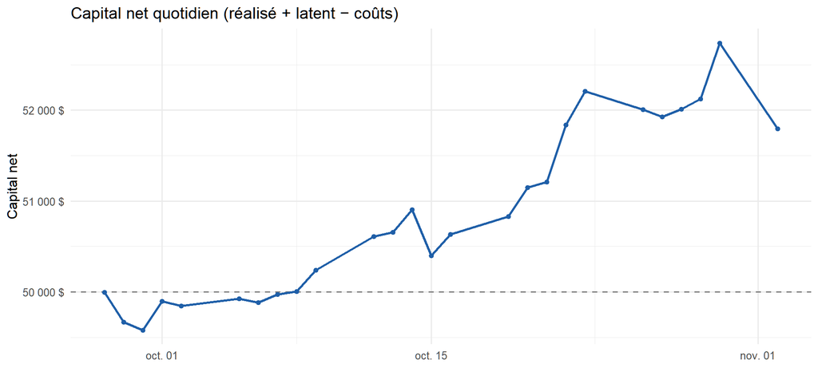

| Date | Réalisé brut $ | Latent $ | Coûts $ | Capital net $ | Var. jour % | Drawdown % | Risque ouvert % |
| --- | --- | --- | --- | --- | --- | --- | --- |
| 28/09/2026 | 0,00 | 0,00 | -4,85 | 49 995,15 | -0,01 | -0,01 | 1,99 |
| 29/09/2026 | 0,00 | -325,83 | -5,73 | 49 668,44 | -0,65 | -0,66 | 1,99 |
| 30/09/2026 | 0,00 | -410,69 | -8,39 | 49 580,92 | -0,18 | -0,84 | 1,99 |
| 01/10/2026 | 0,00 | -92,62 | -9,27 | 49 898,10 | 0,64 | -0,20 | 1,99 |
| 02/10/2026 | 0,00 | -145,15 | -10,16 | 49 844,69 | -0,11 | -0,31 | 1,99 |
| 05/10/2026 | 0,00 | -62,08 | -11,41 | 49 926,51 | 0,16 | -0,15 | 2,98 |
| 06/10/2026 | 0,00 | -105,10 | -12,66 | 49 882,24 | -0,09 | -0,24 | 2,98 |
| 07/10/2026 | 0,00 | -8,86 | -16,40 | 49 974,74 | 0,19 | -0,05 | 2,98 |
| 08/10/2026 | 0,00 | 22,90 | -17,65 | 50 005,25 | 0,06 | 0,00 | 2,98 |
| 09/10/2026 | 0,00 | 260,27 | -18,90 | 50 241,37 | 0,47 | 0,00 | 2,98 |
| 12/10/2026 | 0,00 | 632,84 | -22,02 | 50 610,82 | 0,74 | 0,00 | 3,95 |
| 13/10/2026 | 0,00 | 681,03 | -23,40 | 50 657,64 | 0,09 | 0,00 | 3,95 |
| 14/10/2026 | 0,00 | 934,08 | -27,53 | 50 906,55 | 0,49 | 0,00 | 3,95 |
| 15/10/2026 | 0,00 | 428,81 | -28,91 | 50 399,90 | -1,00 | -1,00 | 3,95 |
| 16/10/2026 | 0,00 | 662,19 | -30,29 | 50 631,90 | 0,46 | -0,54 | 3,95 |
| 19/10/2026 | 0,00 | 859,44 | -31,67 | 50 827,77 | 0,39 | -0,15 | 3,95 |
| 20/10/2026 | 0,00 | 1 181,69 | -33,04 | 51 148,65 | 0,63 | 0,00 | 3,95 |
| 21/10/2026 | 0,00 | 1 246,60 | -37,18 | 51 209,42 | 0,12 | 0,00 | 3,95 |
| 22/10/2026 | 0,00 | 1 873,96 | -38,56 | 51 835,40 | 1,22 | 0,00 | 3,95 |
| 23/10/2026 | 0,00 | 2 249,78 | -39,94 | 52 209,84 | 0,72 | 0,00 | 3,95 |
| 26/10/2026 | -124,23 | 2 172,36 | -40,43 | 52 007,70 | -0,39 | -0,39 | 2,96 |
| 27/10/2026 | -124,23 | 2 092,35 | -40,92 | 51 927,20 | -0,15 | -0,54 | 2,96 |
| 28/10/2026 | -124,23 | 2 182,04 | -46,42 | 52 011,38 | 0,16 | -0,38 | 3,94 |
| 29/10/2026 | -124,23 | 2 295,60 | -47,66 | 52 123,71 | 0,22 | -0,16 | 3,94 |
| 30/10/2026 | -124,23 | 2 910,14 | -48,90 | 52 737,01 | 1,18 | 0,00 | 3,94 |
| 02/11/2026 | 1 843,23 | 0,00 | -48,90 | 51 794,33 | -1,79 | -1,79 | 0,00 |

La perte journalière la plus forte est de -1,79 %, pour une limite de 5 %. Le drawdown maximal est de -1,79 %, pour une limite de 10 %.

## 9.5 Cours, entrées, sorties et stops

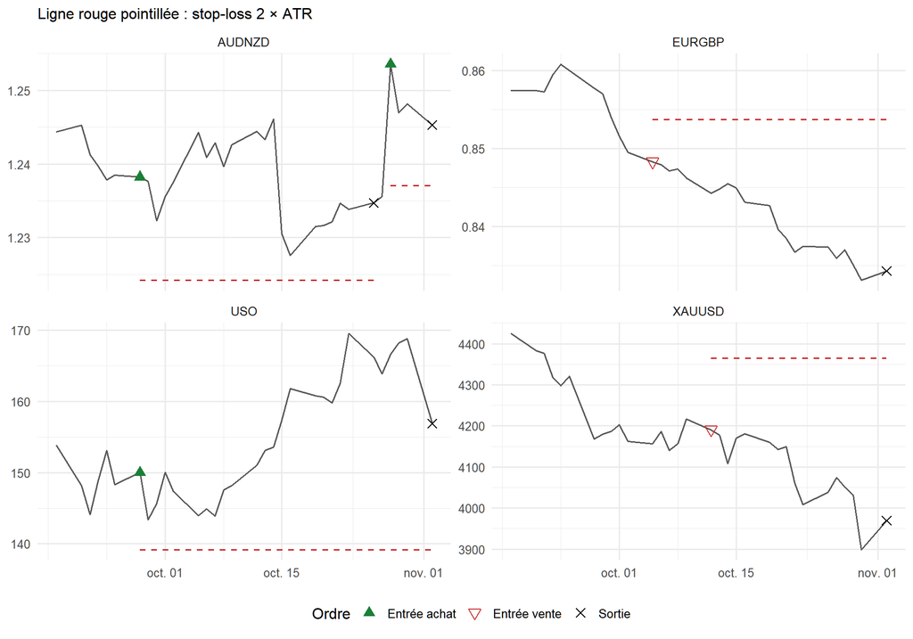

# 10 Décisions quotidiennes générées par R

Chaque ligne donne les valeurs des indicateurs à la clôture, puis la décision du moteur et sa raison. La table peut être filtrée et triée.

| Date | Actif | Clôture | per | ADX | ATR | Tendance hebdo | Position avant | Décision | Position après | Raison |
| --- | --- | --- | --- | --- | --- | --- | --- | --- | --- | --- |
| 2026-09-28 | XAUUSD | 4 168,40 | -7,901 | 16,50 | 103,52 | Haussière | - | AUCUNE | - | Pas de signal : per &lt; 0 mais tendance hebdo haussière (EMA10 &gt; EMA40, semaine du 25/09) (conflit) ; ADX = 16,50 &lt; 17 |
| 2026-09-28 | USO | 150,01 | 1,749 | 25,57 | 5,41 | Haussière | - | ACHAT | Long | ACHAT : per = 1,749 &gt;= 0, ADX = 25,57 &gt;= 17, tendance hebdo haussière (EMA10 &gt; EMA40, semaine du 25/09). Stop = 150,01 - 2 x ATR (5,41) = 139,18 ; taille = 1 % x 50 000,00 $ / (2 x ATR x 1,00… |
| 2026-09-28 | AUDNZD | 1,23822 | 0,002626 | 36,50 | 0,00701 | Haussière | - | ACHAT | Long | ACHAT : per = 0,002626 &gt;= 0, ADX = 36,50 &gt;= 17, tendance hebdo haussière (EMA10 &gt; EMA40, semaine du 25/09). Stop = 1,23822 - 2 x ATR (0,00701) = 1,22420 ; taille = 1 % x 50 000,00 $ / (2 x AT… |
| 2026-09-28 | EURGBP | 0,85778 | 0,0001346 | 18,52 | 0,00233 | Baissière | - | AUCUNE | - | Pas de signal : per &gt;= 0 mais tendance hebdo baissière (EMA10 &lt; EMA40, semaine du 25/09) (conflit) |
| 2026-09-29 | XAUUSD | 4 179,70 | -12 | 17,95 | 101,33 | Haussière | - | AUCUNE | - | Pas de signal : per &lt; 0 mais tendance hebdo haussière (EMA10 &gt; EMA40, semaine du 25/09) (conflit) |
| 2026-09-29 | USO | 143,35 | 1,585 | 24,60 | 5,51 | Haussière | Long | CONSERVER long | Long | Conditions toujours vraies : per = 1,585, ADX = 24,60, tendance hebdo haussière (EMA10 &gt; EMA40, semaine du 25/09) ; stop 139,18 |
| 2026-09-29 | AUDNZD | 1,23767 | 0,002357 | 34,82 | 0,00721 | Haussière | Long | CONSERVER long | Long | Conditions toujours vraies : per = 0,002357, ADX = 34,82, tendance hebdo haussière (EMA10 &gt; EMA40, semaine du 25/09) ; stop 1,22420 |
| 2026-09-29 | EURGBP | 0,85705 | 0,0001294 | 17,57 | 0,00231 | Baissière | - | AUCUNE | - | Pas de signal : per &gt;= 0 mais tendance hebdo baissière (EMA10 &lt; EMA40, semaine du 25/09) (conflit) |
| 2026-09-30 | XAUUSD | 4 186,70 | -15,18 | 18,66 | 99,30 | Haussière | - | AUCUNE | - | Pas de signal : per &lt; 0 mais tendance hebdo haussière (EMA10 &gt; EMA40, semaine du 25/09) (conflit) |
| 2026-09-30 | USO | 145,66 | 1,426 | 23,74 | 5,44 | Haussière | Long | CONSERVER long | Long | Conditions toujours vraies : per = 1,426, ADX = 23,74, tendance hebdo haussière (EMA10 &gt; EMA40, semaine du 25/09) ; stop 139,18 |

[output cut: 94 more lines]

# 11 Contrôle de reproductibilité

Mon journal couvre le 28 septembre au 30 octobre, avec toutes les positions fermées le 30 octobre. Pour le contrôle, le moteur est relancé sur cette même période, aux taux de change du journal (NZDUSD 0,56322 et GBPUSD 1,33910). Il doit retrouver les cinq trades : même actif, même date d’entrée, même quantité et même P&L brut à 0,01 $ près.

```r
attendu <- data.frame(actif = c("USO", "AUDNZD", "EURGBP", "XAUUSD", "AUDNZD"),
                      date_entree = as.Date(c("2026-09-28", "2026-09-28", "2026-10-05", "2026-10-12", "2026-10-28")),
                      lots = c(46, 0.63, 0.68, 0.28, 0.53), pnl = c(865.72, -124.55, 1386.83, 816.76, -161.19))
SPEC_periode <- SPEC                                         # taux du journal (30 oct.) le temps du contrôle
SPEC$AUDNZD$pv <- 1e5 * 0.5632216334342957; SPEC$EURGBP$pv <- 1e5 * 1.3391003608703613
TJ <- simuler_v2(SIG, fin = as.Date("2026-10-30"))$trades
SPEC <- SPEC_periode
k <- merge(attendu, TJ[, c("actif", "date_entree", "lots", "pnl_brut")], by = c("actif", "date_entree"), all.x = TRUE,
           suffixes = c("_journal", "_R"))
k$Verdict <- ifelse(is.na(k$lots_R), "trade absent",
             ifelse(abs(k$lots_journal - k$lots_R) < 1e-9 & abs(k$pnl - k$pnl_brut) < 0.01, "identique", "écart"))
controle_ok <- nrow(TJ) == 5 && all(k$Verdict == "identique")
tab(k[order(k$date_entree), ], row.names = FALSE, col.names = c("Actif", "Entrée", "Quantité (journal)", "P&L brut $ (journal)",
    "Quantité (R)", "P&L brut $ (R)", "Verdict"))
```

| Actif | Entrée | Quantité (journal) | P&L brut $ (journal) | Quantité (R) | P&L brut $ (R) | Verdict |
| --- | --- | --- | --- | --- | --- | --- |
| AUDNZD | 2026-09-28 | 0.63 | -124.55 | 0.63 | -124.5451 | identique |
| USO | 2026-09-28 | 46.00 | 865.72 | 46.00 | 865.7203 | identique |
| EURGBP | 2026-10-05 | 0.68 | 1386.83 | 0.68 | 1386.8259 | identique |
| XAUUSD | 2026-10-12 | 0.28 | 816.76 | 0.28 | 816.7605 | identique |
| AUDNZD | 2026-10-28 | 0.53 | -161.19 | 0.53 | -161.1923 | identique |

**Contrôle OK : sur la période du journal, les 5 trades sont reproduits à 0,01 $ près.**

# 12 Exports

Les mêmes fichiers que le script `GES816_V2_moteur.R`, dans le dossier `sorties/`.

```r
dir.create("sorties", showWarnings = FALSE)
write.csv(TRADES,      "sorties/trades.csv", row.names = FALSE)
write.csv(RES$journal, "sorties/decisions_quotidiennes.csv", row.names = FALSE)
write.csv(COUTS,       "sorties/couts.csv", row.names = FALSE)
write.csv(courbe,      "sorties/courbe_capital.csv", row.names = FALSE)
list.files("sorties")
```

```
## [1] "courbe_capital.csv"         "couts.csv"
## [3] "decisions_quotidiennes.csv" "trades.csv"
```

# 13 Limites et hypothèses

- **Simulation à la clôture.** Les ordres sont exécutés au cours de clôture du jour du signal. Le stop est exécuté au niveau du stop, ou à l’ouverture en cas de gap.
- **Ordre des étapes dans la journée.** Les stops sont traités avant les décisions de clôture. Le capital qui sert à dimensionner une position est le capital initial plus le P&L réalisé brut.
- **Révision des données.** Le cours de clôture de l’or du 30 octobre a été révisé par Yahoo, de 3 884,9 à 3 898,9 (règlement). Ce document utilise 3 898,9.
- **Historique.** Les résultats ne changent pas quand l’historique commence en janvier 2024 ou en janvier 2025. Avec un départ en juin 2025, l’EMA hebdomadaire 40 est moins bien amorcée, et la vente de l’or passe du 12 au 5 octobre.
- **Coûts.** Les swaps et spreads sont ceux affichés le 30 octobre, appliqués à toute la période. Le spread de USO (0,02 $) est une hypothèse.
- **Conversion en dollars.** Le P&L sur AUDNZD et EURGBP est converti en $ aux taux du dernier jour : NZDUSD 0.5618 et GBPUSD 1.34066.
- **Petit échantillon.** Quelques trades sur cinq semaines ne permettent pas de conclure statistiquement à la rentabilité de la méthode.

```
## R version 4.6.1 (2026-06-24 ucrt) | knitr 1.52 | rmarkdown 2.32
```